[figure not shown]

# 01MIAR - Actividad Whitepapers

### Introducción:

- Para abordar un proyecto de Inteligencia Artificial es necesario disponer del conocimiento suficiente tanto a nivel teórico como técnico para garantizar el éxito en la consecución de los objetivos. La fase de investigación sobre la temática de un proyecto es indispensable para conocer nuevos enfoques o afianzar y dar sustento a las acciones que se llevarán a cabo en los trabajos. Los artículos científicos son la referencia más utilizada para investigar sobre un ámbito de conocimiento ya que, antes de su publicación, son aceptados en un proceso llamado “revisión por pares”.

### Objetivo

- Investigar sobre el estado actual del conocimiento sobre procesamiento de datos en trabajos relacionados con Inteligencia Artificial, en concreto, con el uso de Python y librerías.
- El propósito de esta actividad es conocer e indagar en los contenidos definidos en la asignatura Python para la Inteligencia Artificial mediante artículos científicos, siendo estos el marco del conocimiento a investigar.

### Metodología

- Buscar y seleccionar un artículo científico relacionado con la asignatura, es decir, Python o IA.
  - Google Académico (Scholar) es un buscador muy recomendado, aporta una primera idea sobre qué hay publicado y en qué revistas científicas.
  - También se acepatarán artículos publicados en conferencias (proceedings) o "preprints" en [arXiv](https://arxiv.org/) siempre y cuando tengan un formato académico.
  - La fecha de publicación del artículo debe ser actual, no se aceptarán artículos previos al 2024.
- Crear un notebook de Python que servirá como entrega de la actividad (se entregará el fichero .ipynb). En esta entrega se debe:
  - Referenciar adecuadamente este artículo con su estilo de preferencia (IEEE, Harvard, Science).
  - Describir porqué has seleccionado este artículo (trabajo, estudios, hobbies, otros intereses...). Explicar que quieres aprender y su usabilidad.
  - Resumir el contenido del artículo.
  - Seleccionar un ejemplo de implementación con Python. El código puede ser extraído directamente del artículo.
  - Explicar el código implementado.
  - Concluir con un párrafo de reflexión. ¿Qué has aprendido?
- Se recomienda:
  - Formatear bien los apartados propuestos con celdas Markdown o de código según corresponda.
  - Mantener una estructura de código limpia, con comentarios oportunos y tomando en cuenta la secuencia en la que se ejecuta el código.
  - Utilizar un formato adecuado, si aplica, para referencias complementarias.
  - Sintetizar la información, aunque no hay límite de palabras.
  - Mantener una buena ortografía.

**IMPORTANTE:**

- El uso de inteligencia artificial debe estar acorde a la normativa descrita en la guía docente.
- No está permitido compartir los resultados ni el código en ninguno de los foros.

### Evaluación

- Esta actividad corresponde con el 10% de la nota final de la asignatura.

### Entrega:

- Un solo documento en formato notebook: .ipynb
- Las entregas sólo serán validas si se realizan a través del campus virtual: Actividades Formativas, Actividad WhitePapers.

### Fechas Límite

- Convocatoria 1 - 01/06/2026 - 08.00 CET
- Convocatoria 2 - 21/09/2026 - 08.00 CET

### Rúbrica

| Apartados | Criterio 1 | Criterio 2 | Criterio 3 |
| --- | --- | --- | --- |
| Estilo (20%) | Redacción y ortografía | Formato correcto del notebook | Formato de las referencias |
| Artículo (20%) | Relación con la asignatura | Publicación actual | Relevancia académica |
| Contenidos (60%) | Justificación y reflexión | Análisis del artículo | Ejemplo en Python |

## Solución de la Actividad

#### Búsqueda y selección de un artículo científico relacionado con la asignatura

Considerando mi experiencia en programación python y otras disciplinas de mi interés, pensé que podría trabajar en un análisis de análisis financiero de factores, en la que pudiera utilizas los conceptos aprendidos en la materia.

Entonces realicé en la plataforma Google Scholar la siguiente búsqueda: “python machine learning financial factor analysis”. Entre los resultados obtenidos, me resultó interesante el capítulo 1 del libro **Machine Learning in Business Finance Using Python**, “Financial Data Correlations”. Verifiqué que la fecha de publicación de este libro es de Septiembre de 2025, lo cual cumple con la consigna de esta actividad de que el whitepaper sobre el que se haga el trabajo tenga fecha de publicación actual, no previos al 2024. También verifiqué que el trabajo elegido realiza procesamiento de datos en un contexto relacionado con Inteligencia Artificial, que es requisito para esta actividad. Si bien el artículo elegido no es de IA “pura” o modelado de machine learning, en el artículo aparecen tareas típicas de preprocesado de datos, carga de CSV, limpieza, transformación de columnas, cálculo de retornos y optimización de carteras, que son habilidades muy usadas en proyectos de IA y data science y también fueron estudiadas en el transcurso de las clases de la materia. Por último, la elección de este artículo científico fue validado con el Profesor del Curso.

El trabajo elegido es este según su referencia Harvard: Lim, K.G. (2025) **Machine Learning in Business Finance Using Python**. Singapore: World Scientific Publishing.

Mi interés en elegir este artículo fue utilizar tanto los conocimientos de python adquiridos en la materia como los conocimientos que yo adquirí en una Maestría en Finanzas que he realizado en el pasado. Me gustaría aprender la aplicación de las librerías numpy y pandas a esta área de mi interés profesional como es el análisis de factores financieros y de qué manera se pueden usar estas librerías.

#### Resumen del artículo

##### Resumen: Capítulo 1 — Correlaciones en Datos Financieros

##### Idea Central

La idea de las correlaciones de datos financieros (retornos de los activos en un mismo período de tiempo) es la relación fundamental que gobierna la mayoría de las inversiones financieras. Si cada serie de datos financieros, como las tasas de retornos de las acciones, es probabilísticamente independiente de las demás acciones, entonces no existen factores de riesgo sistemáticos que afecten a todas las acciones; cada acción se mueve según su propio riesgo independiente. Esto último no refleja las interrelaciones reales entre el mercado bursátil y el sector corporativo. Las empresas cotizadas sí comparten riesgos comunes, como cuando pertenecen al mismo sector afectado por un cambio sectorial o cuando se ven afectadas por el coste de los fondos al variar los tipos de interés del mercado. Cuando la rentabilidad de las acciones se mueve conjuntamente o presenta correlaciones distintas de cero, pueden combinarse en una cartera de forma óptima para maximizar el beneficio del inversor.

##### 1. Revisión de herramientas Python

El capítulo arranca con un repaso práctico de **NumPy** (operaciones matriciales y arrays) y **Pandas** (manipulación de datos tabulares), que se usan a lo largo de todo el análisis.

##### 2. Diversificación de Portafolios (Markowitz)

- **Frontera eficiente de Markowitz**: representa el límite de portafolios de acciones riesgosas que tienen el menor valor de varianza sobre los retornos dado el valor esperado de retorno para esa combinación de activos y que el retorno esperado sea mayor o igual al retorno del MVP (Minimum variance portfolio). El gráfico de retornos medios versus la volatilidad (o desvío estándar de los retornos, o riesgo) cuando no hay restricciones de ventas en corto tiene la forma de una hipérbola, y es usualmente llamado el portafolio de la frontera eficiente.
- **Máximo Sharpe Ratio**: maximizar el retorno esperado por unidad de riesgo.

El ejemplo práctico usa 7 empresas de e-commerce (Alibaba(BABA.US), Amazon(AMZN.US), eBay (EBAY.US), Rakuten (4755.jp), Wayfair (W.US), Zalando (zal.de), JD.com (JD.US)), con datos descargados del sitio https://stooq.com del período 2017–2021. Los retornos se calculan como logaritmos continuamente compuestos sobre precios ajustados por dividendos y splits. NOTA: he eliminado la empresa Suning incluída en el libro por no haber podido descargar los retornos de esta empresa japonesa.

##### 3. Portafolios Multi-sector

Se amplía el universo a 24 acciones en tres sectores (e-commerce, semiconductores, alimentos). Se demuestra que **la frontera eficiente combinada domina a cada sector por separado**: para igual retorno esperado, la volatilidad es menor — evidencia directa del beneficio de la diversificación. Sin embargo, los pesos óptimos calculados en el conjunto de entrenamiento (2017–2020) **no se transfieren bien** al conjunto de test (2021), porque los retornos futuros difieren de los históricos. Esto ilustra el principal talón de Aquiles de la optimización clásica.

##### 4. Denoising de la Matriz de Correlación

El problema: con N activos y T observaciones finitas, la matriz de correlación muestral es una variable aleatoria, no la verdadera matriz poblacional. El **Teorema de Marchenko–Pastur** establece que, si los datos fueran puro ruido, los autovalores de la matriz de correlación seguirían una distribución teórica acotada entre L y U. Los autovalores **por encima de U ≈ 1,3** (para N=24, T=889) representan señales genuinas del mercado; los que caen por debajo son ruido. **Método de denoising** (constant residual eigenvalue): reemplazar los autovalores menores que U por su promedio (0,5719), preservando la varianza total, y reconstruir la matriz de covarianza. En este caso particular el beneficio fue marginal, probablemente porque el error en la estimación de los retornos esperados domina sobre el error en la covarianza.

##### 5. Predictor Prospectivo Más Preciso

La sección más importante conceptualmente: si se sustituyen los retornos históricos medios por **predicciones más precisas de los retornos futuros**, el portafolio out-of-sample se acerca considerablemente a la frontera eficiente in-sample. Esto demuestra que la calidad de la predicción de retornos es más determinante para el desempeño real que la diversificación en sí misma.

##### 6. Conclusiones

| **Aspecto** | **Limitación** | **Posible mejora con ML** |
| --- | --- | --- |
| Retornos esperados | Se usan medias históricas, que no predicen bien el futuro | Redes neuronales, modelos de factores |
| Covarianza | Estimación ruidosa con muestras finitas | Denoising, GARCH para varianzas |
| Validación | Back-testing sobre ventanas rodantes | Estrategias con significancia estadística de ganancia |

**Librerías utilizadas en el capítulo**: NumPy, Pandas, Matplotlib, Seaborn, SciPy (optimize), scikit-learn (KernelDensity).

#### Selección de un ejemplo de implementación con Python

He seleccionado el código del artículo que corresponde al punto **1.2 Worked example: Data**, que corresponde al punto **2. Diversificación de portfolios (Markowitz)** de este documento.

Para poder obtener los retornos de las empresas seleccionadas, he exportado del sitio stooq.com los retornos diarios entre el 1 de enero de 2017 al 31 de diciembre de 2021 de las empresas con el siguiente criterio:

| **Empresa** | **Ticker** | **Nombre del Archivo con retornos diarios** |
| --- | --- | --- |
| Alibaba | BABA.US | datafiles/baba_us_d.csv |
| Amazon | AMZN.US | datafiles/amzn_us_d.csv |
| Ebay | EBAY.US | datafiles/ebay_us_d.csv |
| Rakuten | 4755.jp | datafiles/4755_jp_d.csv |
| Wayfair | W.US | datafiles/w_us_d.csv |
| Zalando | ZAL.DE | datafiles/zal_de_d.csv |
| JD.com | JD.US | datafiles/jd_us_d.csv |

Ejemplo de la url utilizada para la empres **Alibaba**: https://stooq.com/q/d/?f=20170101&t=20211231&s=BABA.US&c=0

**Requisitos previos:** Antes de ejecutar este notebook, es necesario instalar los paquetes que el notebook requiere en el ambiente python donde se ejecutará. Esto se hace con los siguientes comandos:

```python
!pip install numpy
!pip install pandas
!pip install matplotlib
!pip install scipy
```

**A continuación, se detalla el código elegido para la actividad de Whitepaper:**

```python
### This module computes returns and mean-var frontier given each
###  "expected" return based on averaged realized return
import numpy as np
import pandas as pd
import matplotlib.pyplot as plt
import os
```

```python
import pandas as pd

github_directory = "https://raw.githubusercontent.com/jmaestro-dev/masteria-viu/master/Python-para-IA/Actividades/Whitepaper"
github_datafiles_directory = os.path.join(github_directory, "datafiles")


df = pd.read_csv(os.path.join(github_datafiles_directory, "baba_us_d.csv"), parse_dates=True)
df = df.sort_values(df.columns[0])
df.to_csv("Alibaba_USD_clean.csv", index=False)
df.head()
```

|  | Date | Open | High | Low | Close | Volume |
| --- | --- | --- | --- | --- | --- | --- |
| 0 | 2017-01-03 | 89.000 | 89.00 | 88.08 | 88.60 | 8787301 |
| 1 | 2017-01-04 | 88.985 | 90.89 | 88.58 | 90.51 | 11462690 |
| 2 | 2017-01-05 | 91.910 | 94.81 | 91.64 | 94.37 | 16787882 |
| 3 | 2017-01-06 | 94.400 | 94.50 | 93.00 | 93.89 | 7597313 |
| 4 | 2017-01-09 | 94.160 | 95.65 | 93.31 | 94.72 | 10817809 |

```python
df.info()
```

```
<class 'pandas.core.frame.DataFrame'>
RangeIndex: 1259 entries, 0 to 1258
Data columns (total 6 columns):
 #   Column  Non-Null Count  Dtype
---  ------  --------------  -----
 0   Date    1259 non-null   object
 1   Open    1259 non-null   float64
 2   High    1259 non-null   float64
 3   Low     1259 non-null   float64
 4   Close   1259 non-null   float64
 5   Volume  1259 non-null   int64
dtypes: float64(4), int64(1), object(1)
memory usage: 59.1+ KB
```

```python
df[["year", "month", "day"]] = df["Date"].str.split("-", expand=True)
```

```python
### Above splits the Date entry into 3 separate columns
print("\nNew DataFrame:")
print(df)
```

```
New DataFrame:
            Date     Open    High       Low   Close    Volume  year month day
0     2017-01-03   89.000   89.00   88.0800   88.60   8787301  2017    01  03
1     2017-01-04   88.985   90.89   88.5800   90.51  11462690  2017    01  04
2     2017-01-05   91.910   94.81   91.6400   94.37  16787882  2017    01  05
3     2017-01-06   94.400   94.50   93.0000   93.89   7597313  2017    01  06
4     2017-01-09   94.160   95.65   93.3100   94.72  10817809  2017    01  09
...          ...      ...     ...       ...     ...       ...   ...   ...  ..
1254  2021-12-27  117.800  121.80  116.1021  116.59  17864372  2021    12  27
1255  2021-12-28  116.260  116.42  114.4700  114.80  17052102  2021    12  28
1256  2021-12-29  113.800  114.20  110.3800  112.09  21100463  2021    12  29
1257  2021-12-30  112.630  124.30  112.3000  122.99  45437131  2021    12  30
1258  2021-12-31  121.230  122.91  118.5900  118.79  24287047  2021    12  31

[1259 rows x 9 columns]
```

```python
cols = df.select_dtypes(exclude=['float']).columns
df[cols] = df[cols].apply(pd.to_numeric, downcast='float', errors='coerce')
### Above selects non-float type as cols and converts the Date, day, mth,
### year from objects to float#
### errors = 'coerce' sets invalid parsing as NaN such as Date column above
df.info()
```

```
<class 'pandas.core.frame.DataFrame'>
RangeIndex: 1259 entries, 0 to 1258
Data columns (total 9 columns):
 #   Column  Non-Null Count  Dtype
---  ------  --------------  -----
 0   Date    0 non-null      float32
 1   Open    1259 non-null   float64
 2   High    1259 non-null   float64
 3   Low     1259 non-null   float64
 4   Close   1259 non-null   float64
 5   Volume  1259 non-null   float64
 6   year    1259 non-null   float32
 7   month   1259 non-null   float32
 8   day     1259 non-null   float32
dtypes: float32(4), float64(5)
memory usage: 69.0 KB
```

```python
dfAlibaba = df[(df['year']>=2017)&(df['year']<=2021)]
dfAlibaba = dfAlibaba.drop('Date',axis=1)
### 1 is the axis number (0 for rows and 1 for columns)
### If we do not drop the Date column, Date will be shown as NaN
### Includes only rows where years are between 2017 and 2021 inclusive
### Next remove all columns except keeping Adj Close (closing price including
### dividends and split effects) and day, month, year
dfAlibaba = dfAlibaba[['Close','day','month','year']]
print(dfAlibaba)
```

```
       Close   day  month    year
0      88.60   3.0    1.0  2017.0
1      90.51   4.0    1.0  2017.0
2      94.37   5.0    1.0  2017.0
3      93.89   6.0    1.0  2017.0
4      94.72   9.0    1.0  2017.0
...      ...   ...    ...     ...
1254  116.59  27.0   12.0  2021.0
1255  114.80  28.0   12.0  2021.0
1256  112.09  29.0   12.0  2021.0
1257  122.99  30.0   12.0  2021.0
1258  118.79  31.0   12.0  2021.0

[1259 rows x 4 columns]
```

```python
dfAmazon = pd.read_csv(os.path.join(github_datafiles_directory, "amzn_us_d.csv"), parse_dates=True)
dfAmazon[["year", "month", "day"]] = dfAmazon["Date"].str.split("-", expand = True)
cols = dfAmazon.select_dtypes(exclude=['float']).columns
dfAmazon[cols] = dfAmazon[cols].apply(pd.to_numeric, downcast='float', errors='coerce')
dfAmazon = dfAmazon[(dfAmazon['year']>=2017)&(dfAmazon['year']<=2021)]
dfAmazon = dfAmazon.drop('Date',axis=1)
dfAmazon = dfAmazon[['Close','day','month','year']]
dfAmazon.head()
```

|  | Close | day | month | year |
| --- | --- | --- | --- | --- |
| 0 | 37.6835 | 3.0 | 1.0 | 2017.0 |
| 1 | 37.8590 | 4.0 | 1.0 | 2017.0 |
| 2 | 39.0225 | 5.0 | 1.0 | 2017.0 |
| 3 | 39.7995 | 6.0 | 1.0 | 2017.0 |
| 4 | 39.8460 | 9.0 | 1.0 | 2017.0 |

```python
df.head()
```

|  | Date | Open | High | Low | Close | Volume | year | month | day |
| --- | --- | --- | --- | --- | --- | --- | --- | --- | --- |
| 0 | NaN | 89.000 | 89.00 | 88.08 | 88.60 | 8787301.0 | 2017.0 | 1.0 | 3.0 |
| 1 | NaN | 88.985 | 90.89 | 88.58 | 90.51 | 11462690.0 | 2017.0 | 1.0 | 4.0 |
| 2 | NaN | 91.910 | 94.81 | 91.64 | 94.37 | 16787882.0 | 2017.0 | 1.0 | 5.0 |
| 3 | NaN | 94.400 | 94.50 | 93.00 | 93.89 | 7597313.0 | 2017.0 | 1.0 | 6.0 |
| 4 | NaN | 94.160 | 95.65 | 93.31 | 94.72 | 10817809.0 | 2017.0 | 1.0 | 9.0 |

```python
dfEbay = pd.read_csv(os.path.join(github_datafiles_directory, "ebay_us_d.csv"), parse_dates=True)
dfEbay[["year", "month", "day"]] = dfEbay["Date"].str.split("-", expand = True)
cols = dfEbay.select_dtypes(exclude=['float']).columns
dfEbay[cols] = dfEbay[cols].apply(pd.to_numeric, downcast='float', errors='coerce')
dfEbay = dfEbay[(dfEbay['year']>=2017)&(dfEbay['year']<=2021)]
dfEbay = dfEbay.drop('Date',axis=1)
dfEbay = dfEbay[['Close','year','month','day']]
dfEbay.head()
```

|  | Close | year | month | day |
| --- | --- | --- | --- | --- |
| 0 | 28.1317 | 2017.0 | 1.0 | 3.0 |
| 1 | 28.0548 | 2017.0 | 1.0 | 4.0 |
| 2 | 28.2913 | 2017.0 | 1.0 | 5.0 |
| 3 | 29.2720 | 2017.0 | 1.0 | 6.0 |
| 4 | 28.9882 | 2017.0 | 1.0 | 9.0 |

```python
dfRak = pd.read_csv(os.path.join(github_datafiles_directory, "4755_jp_d.csv"), parse_dates=True)
dfRak[["year", "month", "day"]] = dfRak["Date"].str.split("-", expand = True)
cols = dfRak.select_dtypes(exclude=['float']).columns
dfRak[cols] = dfRak[cols].apply(pd.to_numeric, downcast='float', errors='coerce')
dfRak = dfRak[(dfRak['year']>=2017)&(dfRak['year']<=2021)]
dfRak = dfRak.drop('Date',axis=1)
dfRak = dfRak[['Close','year','month','day']]
dfRak.head()
```

|  | Close | year | month | day |
| --- | --- | --- | --- | --- |
| 0 | 1170.0 | 2017.0 | 1.0 | 4.0 |
| 1 | 1180.0 | 2017.0 | 1.0 | 5.0 |
| 2 | 1221.5 | 2017.0 | 1.0 | 6.0 |
| 3 | 1213.5 | 2017.0 | 1.0 | 10.0 |
| 4 | 1216.5 | 2017.0 | 1.0 | 11.0 |

```python
dfWay = pd.read_csv(os.path.join(github_datafiles_directory, "w_us_d.csv"), parse_dates=True)
dfWay[["year", "month", "day"]] = dfWay["Date"].str.split("-", expand = True)
cols = dfWay.select_dtypes(exclude=['float']).columns
dfWay[cols] = dfWay[cols].apply(pd.to_numeric, downcast='float', errors='coerce')
dfWay= dfWay[(dfWay['year']>=2017)&(dfWay['year']<=2021)]
dfWay = dfWay.drop('Date',axis=1)
dfWay = dfWay[['Close','year','month','day']]
dfWay.head()
```

|  | Close | year | month | day |
| --- | --- | --- | --- | --- |
| 0 | 35.18 | 2017.0 | 1.0 | 3.0 |
| 1 | 36.48 | 2017.0 | 1.0 | 4.0 |
| 2 | 37.17 | 2017.0 | 1.0 | 5.0 |
| 3 | 37.36 | 2017.0 | 1.0 | 6.0 |
| 4 | 38.05 | 2017.0 | 1.0 | 9.0 |

```python
dfZal = pd.read_csv(os.path.join(github_datafiles_directory, "zal_de_d.csv"), parse_dates=True)
dfZal[["year", "month", "day"]] = dfZal["Date"].str.split("-", expand = True)
cols = dfZal.select_dtypes(exclude=['float']).columns
dfZal[cols] = dfZal[cols].apply(pd.to_numeric, downcast='float', errors='coerce')
dfZal= dfZal[(dfZal['year']>=2017)&(dfZal['year']<=2021)]
dfZal = dfZal.drop('Date',axis=1)
dfZal = dfZal[['Close','year','month','day']]
dfZal.head()
```

|  | Close | year | month | day |
| --- | --- | --- | --- | --- |
| 0 | 36.905 | 2017.0 | 1.0 | 2.0 |
| 1 | 37.315 | 2017.0 | 1.0 | 3.0 |
| 2 | 35.920 | 2017.0 | 1.0 | 4.0 |
| 3 | 36.765 | 2017.0 | 1.0 | 5.0 |
| 4 | 37.350 | 2017.0 | 1.0 | 6.0 |

```python
dfJD = pd.read_csv(os.path.join(github_datafiles_directory, "jd_us_d.csv"), parse_dates=True)
dfJD[["year", "month", "day"]] = dfJD["Date"].str.split("-", expand = True)
cols = dfJD.select_dtypes(exclude=['float']).columns
dfJD[cols] = dfJD[cols].apply(pd.to_numeric, downcast='float', errors='coerce')
dfJD= dfJD[(dfJD['year']>=2017)&(dfJD['year']<=2021)]
dfJD = dfJD.drop('Date',axis=1)
dfJD = dfJD[['Close','year','month','day']]
dfJD.head()
```

|  | Close | year | month | day |
| --- | --- | --- | --- | --- |
| 0 | 25.1947 | 2017.0 | 1.0 | 3.0 |
| 1 | 25.2239 | 2017.0 | 1.0 | 4.0 |
| 2 | 25.6630 | 2017.0 | 1.0 | 5.0 |
| 3 | 25.6338 | 2017.0 | 1.0 | 6.0 |
| 4 | 25.6240 | 2017.0 | 1.0 | 9.0 |

```python
### merging all 8 data files by same day, month, year -- those that do not overlap are eliminated
dfmerge = pd.merge(dfAlibaba,dfAmazon,on = ['day', 'month','year'])
dfmerge.columns=['Alibaba','day','month','year','Amazon'] ### Rename the columns
dfmerge = pd.merge(dfmerge,dfEbay,on = ['day', 'month','year'])
dfmerge.columns=['Alibaba','day','month','year','Amazon','Ebay']
dfmerge = pd.merge(dfmerge,dfRak, on = ['day', 'month','year'])
dfmerge.columns=['Alibaba','day','month','year','Amazon','Ebay','RakutenP']
dfmerge = pd.merge(dfmerge,dfWay,on = ['day', 'month','year'])
dfmerge.columns=['Alibaba','day', 'month','year','Amazon','Ebay','RakutenP','Wayfair']
dfmerge = pd.merge(dfmerge,dfZal,on = ['day', 'month','year'])
dfmerge.columns=['Alibaba','day', 'month','year','Amazon','Ebay','RakutenP','Wayfair','Zalando']
dfmerge = pd.merge(dfmerge,dfJD,on = ['day', 'month','year'])
dfmerge.columns=['Alibaba','day','month','year','Amazon','Ebay','RakutenP','Wayfair','Zalando','JDcomp']
```

```python
print(dfmerge)
```

```
      Alibaba   day  month    year    Amazon     Ebay  RakutenP  Wayfair  \
0       90.51   4.0    1.0  2017.0   37.8590  28.0548    1170.0    36.48
1       94.37   5.0    1.0  2017.0   39.0225  28.2913    1180.0    37.17
2       93.89   6.0    1.0  2017.0   39.7995  29.2720    1221.5    37.36
3       96.75  10.0    1.0  2017.0   39.7950  28.5159    1213.5    41.04
4       96.94  11.0    1.0  2017.0   39.9510  28.6688    1216.5    40.85
...       ...   ...    ...     ...       ...      ...       ...      ...
1153   118.66  23.0   12.0  2021.0  171.0680  63.6907    1124.0   204.37
1154   116.59  27.0   12.0  2021.0  169.6700  64.4465    1135.0   198.88
1155   114.80  28.0   12.0  2021.0  170.6610  64.8587    1150.0   192.86
1156   112.09  29.0   12.0  2021.0  169.2010  65.2321    1164.0   191.72
1157   122.99  30.0   12.0  2021.0  168.6440  65.5455    1154.0   192.81

      Zalando   JDcomp
0      35.920  25.2239
1      36.765  25.6630
2      37.350  25.6338
3      37.240  26.2192
4      38.145  26.1217
...       ...      ...
1153   70.520  66.9874
1154   70.460  66.0701
1155   70.800  64.2747
1156   70.700  64.0405
1157   71.140  68.6950

[1158 rows x 10 columns]
```

```python
### Now delete columns day, month, year; but before that keep day,
### month, year separately for later concatenation
dy=dfmerge["day"]
mth=dfmerge["month"]
yr=dfmerge["year"]
del(dfmerge['day'],dfmerge['month'],dfmerge['year'])
print(dfmerge)
```

```
      Alibaba    Amazon     Ebay  RakutenP  Wayfair  Zalando   JDcomp
0       90.51   37.8590  28.0548    1170.0    36.48   35.920  25.2239
1       94.37   39.0225  28.2913    1180.0    37.17   36.765  25.6630
2       93.89   39.7995  29.2720    1221.5    37.36   37.350  25.6338
3       96.75   39.7950  28.5159    1213.5    41.04   37.240  26.2192
4       96.94   39.9510  28.6688    1216.5    40.85   38.145  26.1217
...       ...       ...      ...       ...      ...      ...      ...
1153   118.66  171.0680  63.6907    1124.0   204.37   70.520  66.9874
1154   116.59  169.6700  64.4465    1135.0   198.88   70.460  66.0701
1155   114.80  170.6610  64.8587    1150.0   192.86   70.800  64.2747
1156   112.09  169.2010  65.2321    1164.0   191.72   70.700  64.0405
1157   122.99  168.6440  65.5455    1154.0   192.81   71.140  68.6950

[1158 rows x 7 columns]
```

```python
dfret=dfmerge.pct_change().apply(lambda x: np.log(1+x))
### Lambda is an alternative way of defining function inline using a single line of
### python code. percent change = x.
### Pandas -- Computes the percentage change from the immediately previous row by default
### Note the time series is in ascending order of time (ie later rows are later in time)
dfret=dfret.iloc[1:len(dfret.index),:]
### Remove NaN values at the first row. Note iloc[0:,...,:] indicates first row
dfret.columns=['AlibabaP','AmazonP','EbayP','RakutenP','WayfairP','ZalandoP','JDcomP']
### Rename the columns
```

```python
print(dfret)
```

```
      AlibabaP   AmazonP     EbayP  RakutenP  WayfairP  ZalandoP    JDcomP
1     0.041763  0.030270  0.008395  0.008511  0.018738  0.023252  0.017258
2    -0.005099  0.019716  0.034077  0.034565  0.005099  0.015787 -0.001138
3     0.030006 -0.000113 -0.026170 -0.006571  0.093947 -0.002949  0.022580
4     0.001962  0.003912  0.005348  0.002469 -0.004640  0.024011 -0.003726
5    -0.010786  0.018132 -0.001994 -0.029616 -0.011820  0.013281 -0.005998
...        ...       ...       ...       ...       ...       ...       ...
1153  0.007189  0.000181  0.014746  0.005352  0.002842  0.007973 -0.071660
1154 -0.017599 -0.008206  0.011797  0.009739 -0.027230 -0.000851 -0.013788
1155 -0.015472  0.005824  0.006376  0.013129 -0.030737  0.004814 -0.027550
1156 -0.023889 -0.008592  0.005741  0.012100 -0.005929 -0.001413 -0.003650
1157  0.092801 -0.003297  0.004793 -0.008628  0.005669  0.006204  0.070161

[1157 rows x 7 columns]
```

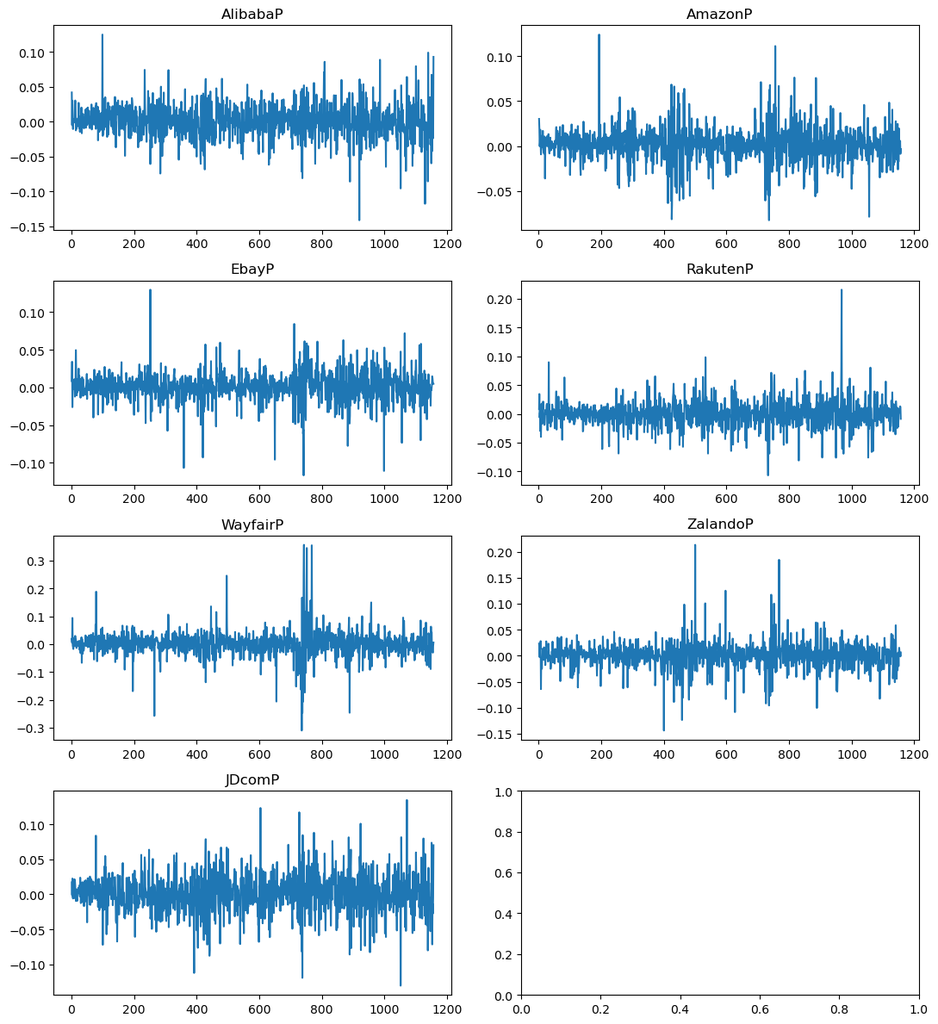

```python
# He modificado aquí el código propuesto en el libro, utilizando directamente el método `plot` de Matplotlib.
# Esta versión de Matplotlib es más sencilla y evita las reglas de manejo de dataframes de Seaborn.
# Seaborn añade estilos y convenciones de trazado, mientras que Matplotlib ofrece un gráfico de líneas más directo con menor sobrecarga.

fig, axs = plt.subplots(ncols=2, nrows=4, figsize=(11, 12))
axs = axs.flatten()

for i, (k, v) in enumerate(dfret.items()):
    axs[i].plot(v.index, v.values)
    axs[i].set_title(k)

plt.tight_layout()
plt.show()
```

```python
# Finding the simple covariance matrix from a series of returns
covar = dfret.cov()
print(covar)
```

```
          AlibabaP   AmazonP     EbayP  RakutenP  WayfairP  ZalandoP    JDcomP
AlibabaP  0.000567  0.000205  0.000138  0.000041  0.000306  0.000126  0.000426
AmazonP   0.000205  0.000366  0.000133  0.000019  0.000305  0.000128  0.000232
EbayP     0.000138  0.000133  0.000385  0.000035  0.000276  0.000123  0.000156
RakutenP  0.000041  0.000019  0.000035  0.000524  0.000114  0.000061  0.000040
WayfairP  0.000306  0.000305  0.000276  0.000114  0.002086  0.000378  0.000364
ZalandoP  0.000126  0.000128  0.000123  0.000061  0.000378  0.000623  0.000189
JDcomP    0.000426  0.000232  0.000156  0.000040  0.000364  0.000189  0.000774
```

```python
# Finding the simple correlation matrix from a series of returns
corr_matrix = dfret.corr()
print(corr_matrix)
```

```
          AlibabaP   AmazonP     EbayP  RakutenP  WayfairP  ZalandoP    JDcomP
AlibabaP  1.000000  0.451313  0.296381  0.075337  0.281793  0.211414  0.642883
AmazonP   0.451313  1.000000  0.353781  0.044433  0.349527  0.267832  0.436737
EbayP     0.296381  0.353781  1.000000  0.078191  0.308661  0.251624  0.286459
RakutenP  0.075337  0.044433  0.078191  1.000000  0.108846  0.106364  0.062423
WayfairP  0.281793  0.349527  0.308661  0.108846  1.000000  0.331254  0.286396
ZalandoP  0.211414  0.267832  0.251624  0.106364  0.331254  1.000000  0.272256
JDcomP    0.642883  0.436737  0.286459  0.062423  0.286396  0.272256  1.000000
```

```python
count = np.isinf(dfret).values.sum()
print(count)
```

```
0
```

```python
dfcumuret = (np.exp(dfret)).cumprod()
print(dfcumuret)
```

```
      AlibabaP   AmazonP     EbayP  RakutenP  WayfairP  ZalandoP    JDcomP
1     1.042647  1.030732  1.008430  1.008547  1.018914  1.023524  1.017408
2     1.037344  1.051256  1.043387  1.044017  1.024123  1.039811  1.016250
3     1.068943  1.051137  1.016436  1.037179  1.125000  1.036748  1.039459
4     1.071042  1.055258  1.021886  1.039744  1.119792  1.061943  1.035593
5     1.059551  1.074566  1.019850  1.009402  1.106634  1.076141  1.029401
...        ...       ...       ...       ...       ...       ...       ...
1153  1.311015  4.518556  2.270225  0.960684  5.602248  1.963252  2.655711
1154  1.288145  4.481629  2.297165  0.970085  5.451754  1.961581  2.619345
1155  1.268368  4.507805  2.311858  0.982906  5.286732  1.971047  2.548167
1156  1.238427  4.469241  2.325167  0.994872  5.255482  1.968263  2.538882
1157  1.358855  4.454529  2.336338  0.986325  5.285362  1.980512  2.723409

[1157 rows x 7 columns]
```

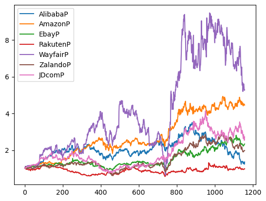

```python
fig = plt.figure()
(np.exp(dfret)).cumprod().plot()
plt.show()
```

```python
import scipy
from scipy.optimize import Bounds
bounds = Bounds(0, 1)

from scipy.optimize import LinearConstraint
linear_constraint = LinearConstraint(np.ones((dfret.shape[1],), dtype=int), 1, 1)

covar = dfret.cov()
r = np.mean(dfret, axis=0) * 252

def ret(r, w):
    return r.dot(w)

def vol(w, covar):
    return np.sqrt(np.dot(w, np.dot(w, covar)) * 252)

def sharpe(ret, vol):
    return ret / vol

from scipy.optimize import minimize
weights = np.ones(dfret.shape[1])
x0 = weights / np.sum(weights)

portfstderr = lambda w: np.sqrt(np.dot(w, np.dot(w, covar)) * 252)
res1 = minimize(portfstderr, x0, method='trust-constr', constraints=linear_constraint, bounds=bounds)

w_min = res1.x
np.set_printoptions(suppress = True, precision=3)
print(w_min)
print('return: % .4f'% (ret(r,w_min)), 'risk: % .4f'% vol(w_min,covar))
```

```
[0.096 0.259 0.25  0.273 0.    0.122 0.   ]
return:  0.1542 risk:  0.2060
```

```python
### Define 1/Sharpe_ratio as invSharpe
invSharpe = lambda w: np.sqrt(np.dot(w,np.dot(w,covar))*252)/r.dot(w)
res2 = minimize(invSharpe,x0,method='trust-constr',constraints = linear_constraint,bounds = bounds)
### Objective function is invSharpe -- inverse of Sharpe ratio
### These are the weights of the stocks in the portfolio with the highest Sharpe ratio
### -- call the weight vector w_Sharpe

w_Sharpe = res2.x
### constraint means unit vector .dot(w) = 1; minimize chooses wts w
### optimization full output.x gives the solution array of optimal weights in min inverse Sharpe
### ratio or max Sharpe ratio

print(w_Sharpe)
print('return: % .4f'% (ret(r,w_Sharpe)), 'risk: % .4f'% vol(w_Sharpe,covar))
### this is max Sharpe ratio portfolio

print( 1/ ( np.sqrt(np.dot(w_Sharpe,np.dot(w_Sharpe,covar))*252)/r.dot(w_Sharpe) ) )
### Above is optimized objective function -- the max Sharpe ratio.
### It can also be found using print(sharpe(ret(r,w_Sharpe),vol(w_Sharpe,covar)))
```

```
[0.    0.774 0.174 0.    0.03  0.022 0.   ]
return:  0.2980 risk:  0.2710
1.0998715406547999
```

```python
# En este fragmento del código, he tenido que agregar la primera línea que en el libro no estaba presente, haciendo que el código falle.
```

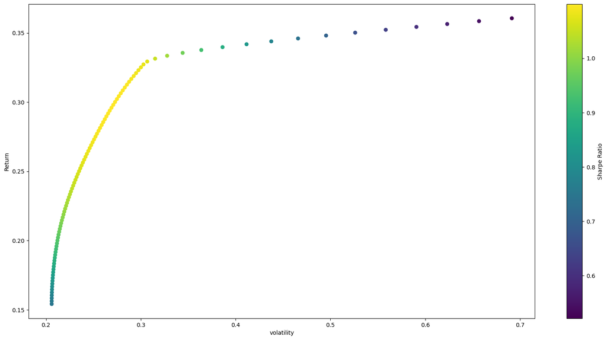

```python
decovar = covar.copy()

w = w_min ### w is now optimal portfolio weights, sum to 1
num_ports = 100
gap = (np.amax(r) - ret(r,w_min))/num_ports
### np.amax in numpy returns max in the array -- since weights sum to 1 and are
### bounded in (0,1), max portf ret is amax(r)
### The aboove range given by gap starts at ret given by Min Var Portf to Max of all mean returns

all_weights = np.zeros((num_ports, len(dfret.columns)))
### all_weights is 20 100 x 8 zero matrix
### Note: len(dfret.columns) is 8 -- there are 8 stocks here
### print(np.shape(all_weights)) gives (100,8) - same as print(all_weights.shape) that gives (100,8)

print("************************************************************")
###########################################################################################
### First note that in Python, a Tuple is a grouping of unnamed, ordered values that can be
### of different types; an array is a collection where elements' values can be changed, and
### are of a single type. ALL_weights is a 2D array of 100 rows each with 8 cols.
### all_weight[0] below is the first 1D sub-array that is 1st row
### Note: all_weights[0] is [0. 0. 0. 0. 0. 0. 0. 0.], i.e. first row of 100 x 8 all_weight
### Note: all_weights[1] is [0. 0. 0. 0. 0. 0. 0. 0.], i.e. second row of 100 x 8 all_weight
### ..........
### Note: all_weights[99 is [0. 0. 0. 0. 0. 0. 0. 0.], i.e. 100th row of 100 x 8 all_weight
### print(all_weights[0].shape) gives (8,) -- a 1-tuple with 8 elements
### print(all_weights.shape[0]) gives 100, i.e. dimension of the rows
### print(all_weights.shape[1]) gives 8, i.e. dim of the cols
###########################################################################################

ret_arr = np.zeros(num_ports) ### this is a 1-tuple of 100 zeros
### Note: print(ret_arr.shape) gives (100,) -- this is a 1D tuple
### print(ret_arr.shape[0]) gives 100, the number of elements in 1D tuple
### if we print(ret_arr.shape[1]) - this gives "tuple index out of range" as there is no other dim
### If we use instead ret_arr = np.zeros((num_ports,1)), then print(ret_arr.shape)
### gives (100,1), a dataframe with one column

vol_arr = np.zeros(num_ports)

for i in range(num_ports): ### this means looping from i=0 to 1,2,3,4,....,99 (100 loops in total)
    port_ret = ret(r,w) + i*gap
    double_constraint = LinearConstraint([np.ones(dfret.shape[1]),r],[1,port_ret],[1,port_ret])
### above means left term in first bracket np.ones(dfret.shape[1]) or A * w >< first term
### in 2nd,3rd brackets 1,1;
### right term in first bracket r * w >< second terms in 2nd, 3rd brackets port_ret
### i.e. constraints port wts sum to 1 and portf exp return == port_ret

### Create x0: initial guesses for weights.
    x0 = w_min
### Define a function for annualized portfolio volatility.
    portfvol = lambda w: np.sqrt(np.dot(w,np.dot(w,decovar))*252)
    res = minimize(portfvol,x0,method='trust-constr',constraints = double_constraint,bounds = bounds)
### Above double constraints mean unit vector .dot(w) = 1; r .dot(w) = port_ret; minimize chooses wts w
    all_weights[i,:]=res.x ### 24 x 1 optimal wts at row i, formed using decovar
    ret_arr[i]=port_ret
    vol_arr[i]=vol(res.x,decovar)

### Indented paras after "for i..." form the loop

sharpe_arr = ret_arr/vol_arr ### sharpe_arr is 100 x 1 array since it is ret_arr[100]/vol_arr[100] element by element

plt.figure(figsize=(20,10)) ### optimal frontier using training set and decovar
plt.scatter(vol_arr, ret_arr, c=sharpe_arr, cmap='viridis')
### in plt.scatter, c is a scalar or sequence of n numbers to be mapped to colors using cmap
### in plt, for sequential plots, 'viridis' gives colors across the 3D representation of vol_arr, ret_arr, sharpe_arr
### c= in front of third dimension sharpe_arr gives the colors in that dimension, otherwise dots will be all blue
plt.colorbar(label='Sharpe Ratio')
plt.xlabel('volatility')
plt.ylabel('Return')
plt.show()
```

```python
dfret.shape
```

```
(1157, 7)
```

```python
t1=pd.concat([dy,mth,yr], axis=1) #Axis = 1 is important -- aligning columns
t1=t1.iloc[1:,:]
print(t1)
```

```
       day  month    year
1      5.0    1.0  2017.0
2      6.0    1.0  2017.0
3     10.0    1.0  2017.0
4     11.0    1.0  2017.0
5     12.0    1.0  2017.0
...    ...    ...     ...
1153  23.0   12.0  2021.0
1154  27.0   12.0  2021.0
1155  28.0   12.0  2021.0
1156  29.0   12.0  2021.0
1157  30.0   12.0  2021.0

[1157 rows x 3 columns]
```

```python
t1.shape
```

```
(1157, 3)
```

```python
dfret1=pd.concat([dfret, t1],axis=1)
```

```python
import pandas as pd
dfret1.to_csv('datafiles/ret_portecom.csv')
```

#### Explicación del código implementado

##### Lectura de archivo .csv a un dataframe

El código comienza leyendo los retornos diarios de los archivos .csv y realizando algunas transformaciones iniciales:

- Agrega columnas **year**, **month** y **day**, tomando el valor del campo "Date" del dataframe y separando los campos por el separador **-**.
- Los valores de estas columnas son seteados a **flota**.
- También filtra las filas donde el año no esté entre 2017 y 2021.
- Elimina la columna **Date**.
- Por último, asigna a la variable donde asignó el dataframe únicamente las columnas **Close**, **day**, **month** y **year**.

```
dfAmazon = pd.read_csv(os.path.join(github_datafiles_directory, 'amzn_us_d.csv'),parse_dates=True)
dfAmazon[["year", "month", "day"]] = dfAmazon["Date"].str.split("-", expand = True)
cols = dfAmazon.select_dtypes(exclude=['float']).columns
dfAmazon[cols] = dfAmazon[cols].apply(pd.to_numeric, downcast='float', errors='coerce')
dfAmazon = dfAmazon[(dfAmazon['year']>=2017)&(dfAmazon['year']<=2021)]
dfAmazon = dfAmazon.drop('Date',axis=1)
dfAmazon = dfAmazon[['Close','day','month','year']]
dfAmazon.head()
```

Este procedimiento se repite para todas las empresas del análisis.

##### Merge de los retornos diarios de todas las empresas.

El precio ajustado de cierre de las acciones de las distintas empresas son combinados de manera que únicamente todos los precios de cierre ajustados para el mismo día, mes y año sean incluídos. (Por ejemplo, si en alguna fecha el mercado donde una de las empresas huiera estado cerrado, esa fecha se eliminará del análisis para todas las empresas)

##### Cálculo de la tasa de retorno compuesta

Se calcula esta tasa que también se puede expresar como ln [1 + (P<sub>t+1</sub> /P<sub>t</sub> - 1)].

##### Gráficos de los retornos diarios

Se realizan gráficos de los retornos diarios de todas las empresas seleccionadas.

##### Cálculo de los retornos diarios acumulados y gráficos

Se calculan los retornos diarios acumulados y luego se grafican.

##### Portafolios óptimo

Por último, se obtienen los pesos de las acciones de las 7 empresas que forman el portafolios óptimo. Estos pesos son la solución a un problema de minimización donde la función objetivo es el error standard del retorno anual del portafolio. Las medidas clave de retorno medio y desvío estandard de este retorno están expresados en valores anualizados y se calculan de la siguiente manera:

- para una acción determinada <sub>i</sub>, su retorno actualizado es 252 * $r^*_{it}$, donde $r^*_{it}$ es la tasa de retorno diaria y es considerada incondicionalmente estacionaria (con la misma media y varianza cada vez). Entonces, la media del retorno anual es 252 * E($r^*_{it}$) donde E(.) es el operador correspondiente a la Esperanza estadística y E($r^*_{it}$) es estimado usando 1/T $\sum_{t=1}^{T} r^*_{it}$ con los retornos diarios $r^*_{it}$ , t=1,2,...,T. La media del retorno anualizado es 252 1/T $\sum_{t=1}^{T} r^*_{it}$ donde 252 es el valor aproximado de días donde hay trading de acciones en los Estados Unidos.
- para una acción determinada <sub>i</sub>, donde i=1, 2, ..., N con un retorno diario r*<sub>t</sub> en el día t, cada elemento <sub>ij</sub> de la covarianza $r^**{it}$ y $r^**{ij}$ es estimado como \ 1/(T-k) $\sum_{t=1}^{T} (r^*_{it}-\mu_i)(r^*_{jt}-\mu_j)$ \ donde k=1 para i=j, y k=2 para $i \neq j$.

La matriz covarianza puede ser denotada en la forma var($r^*_t$). La volatilidad del retorno del portafolios es entonces  
$\sqrt{252 x (w~T~var(r^*_t)~w)}$  
o bien

```
np.sqrt(np.dot(w,np.dot(w,covar))*252)
```

```
w_min = res1.x
np.set_printoptions(suppress = True, precision=3)
print(w_min)
print('return: % .4f'% (ret(r,w_min)), 'risk: % .4f'% vol(w_min,covar))
```

Cuando ejecutamos este código, obtenemos los siguientes resultados:

```
[0.096 0.259 0.25  0.273 0.    0.122 0.   ]
return:  0.1542 risk:  0.2060
```

Esto se debe interpretar como un portafolios óptimo con los siguientes pesos para las acciones que lo componen:

- 9.6% para Alibaba
- 25.9% para Amazon
- 25% para Ebay
- 27.3% para Rakuten
- 0% para Wayfare
- 12.2% para Zalando
- 0% para JD.com

Y con este portafolio, se obtiene un retorno esperado de 15.42% y un riesgo o desvío estandard de 20.6%

Para el cálculo del ratio de Sharpe (retorno esperado sobre desvío estándard), tenemos este código:

```
invSharpe = lambda w: np.sqrt(np.dot(w,np.dot(w,covar))*252)/r.dot(w)
res2 = minimize(invSharpe,x0,method='trust-constr',constraints = linear_constraint,bounds = bounds)
w_Sharpe = res2.x
print(w_Sharpe)
print('return: % .4f'% (ret(r,w_Sharpe)), 'risk: % .4f'% vol(w_Sharpe,covar))
print( 1/ ( np.sqrt(np.dot(w_Sharpe,np.dot(w_Sharpe,covar))*252)/r.dot(w_Sharpe) ) )
```

Cuando ejecutamos este código, obtenemos los siguientes resultados:

```
[0.    0.774 0.174 0.    0.03  0.022 0.   ]
return:  0.2980 risk:  0.2710
1.0998715406547999
```

Esto significa que la solución para el ratio de Sharpe maximizado es 1.0999, mientras que el retorno esperado del portafolos es 29.8% y desvío estándard de 27.10%

Por último, la frontera de portafolios eficiente de acuerdo a los criterios de media y varianza es graficada bajo las restricciones de pesos positivos para todas las acciones del portafolios. Diferentes retornos esperados dan lugar a diferentes volatilidades minimizadas y esto es lo que el gráfico muestra:

[figure not shown]

#### Reflexión final

Este artículo presenta la implementación en lenguaje python de un tema central en el análisis financiero como es el del análisis MVP en un portafolios y la determinación de su frontera eficiente. Estas teorías fueron desarrolladas por el Premio Nobel de Economía Harry Markowitz (1990).

El lenguaje de programación **python** junto con las librerías **numpy** y **pandas** son herramientas poderosísimas para la manipulación de datos y los cálculos que se realizan con estos datos, proveyendo también valiosas herramientas para la visualización de los resultados obtenidos.

#### Declaración del uso de la IA

He utilizado la IA para obtener ayuda sobre cómo usar el lenguaje markdown para las expresiones matemáticas que se incluyen en el Trabajo Práctico.